# notebook

2023-03-02

# Hoja de trabajo 03 - Regresión Lineal

```r
library(dplyr)
```

```r
library(knitr)
library(ggplot2)
library(cluster)
library(factoextra)
require(caret)
library(corrplot)
options(dplyr.summarise.inform = FALSE)
```

```r
data <- read.csv("train.csv")
```

## Análisis Exploratorio

### ¿Cuál es la Zona más cara?

```r
grouped_data <- data %>% group_by(MSZoning)
agg_tbl <- grouped_data %>% summarise(median(SalePrice))
grouped_dataset <- as.data.frame(agg_tbl)
colnames(grouped_dataset)[colnames(grouped_dataset) == "MSZoning"] ="Zona"
colnames(grouped_dataset)[colnames(grouped_dataset) == "median(SalePrice)"] ="Promedio de Precio (USD)"
grouped_dataset <- grouped_dataset[order(grouped_dataset$`Promedio de Precio (USD)`, decreasing = TRUE), ]
kable(grouped_dataset, caption = "Promedio de ventas por cada zona")
```

Promedio de ventas por cada zona

|  | Zona | Promedio de Precio (USD) |
| --- | --- | --- |
| 2 | FV | 205950 |
| 4 | RL | 174000 |
| 3 | RH | 136500 |
| 5 | RM | 120500 |
| 1 | C (all) | 74700 |

### ¿En qué vecindario se ubican las casas con mayor área en su terreno?

```r
grouped_area_data <- data %>% group_by(Neighborhood)
area_with_median <- grouped_area_data %>% summarise(median(LotArea))
grouped_dataset_lot <- as.data.frame(area_with_median)
colnames(grouped_dataset_lot)[colnames(grouped_dataset_lot) == "Neighborhood"] ="Vecindario"
colnames(grouped_dataset_lot)[colnames(grouped_dataset_lot) == "median(LotArea)"] ="Area del terreno ft^2"
grouped_dataset_lot <- grouped_dataset_lot[order(grouped_dataset_lot$`Area del terreno ft^2`, decreasing = TRUE), ]
kable(grouped_dataset_lot[0:5,], caption = "Mediana de area por cada vecindario")
```

Mediana de area por cada vecindario

|  | Vecindario | Area del terreno ft^2 |
| --- | --- | --- |
| 5 | ClearCr | 17575.0 |
| 24 | Timber | 12781.5 |
| 16 | NoRidge | 12090.0 |
| 17 | NridgHt | 11694.0 |
| 7 | Crawfor | 11500.0 |

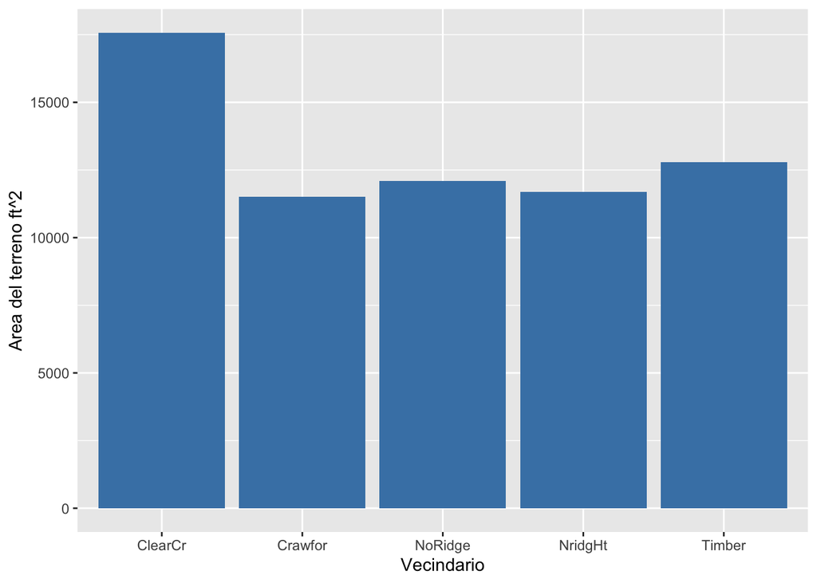

```r
ggplot(grouped_dataset_lot[0:5,], aes(x=Vecindario, y=`Area del terreno ft^2`)) +
geom_bar(stat="identity", fill="steelblue")
```

La información nos demuestra que Clear Creek es el vecindario que tiene los terrenos con mayor área. Un 50% de los terrenos tiene un área mayor a 17575.0 pies cuadrados.

### ¿En qué año hubo más remodelaciones?

```r
data_with_remodelation <- data[data$YearBuilt != data$YearRemodAdd,]
```

En el dataset hay 696 registros de casas que fueron remodeladas. A continuación agrupamos por año la cantidad de remodelaciones.

```r
grouped_remodelation_data <- data_with_remodelation %>% group_by(YearRemodAdd)
year_with_count <- grouped_remodelation_data %>% summarise(total_count=n(),
            .groups = 'drop')

grouped_remodelation <- as.data.frame(year_with_count)
colnames(grouped_remodelation)[colnames(grouped_remodelation) == "YearRemoAdd"] ="Año"
colnames(grouped_remodelation)[colnames(grouped_remodelation) == "total_count"] ="Cantidad de casas remodeladas"
grouped_remodelation <- grouped_remodelation[order(grouped_remodelation$`Cantidad de casas remodeladas`, decreasing = TRUE), ]
kable(grouped_remodelation[0:5,], caption = "Numero de casas Remodeladas por año")
```

Numero de casas Remodeladas por año

|  | YearRemodAdd | Cantidad de casas remodeladas |
| --- | --- | --- |
| 1 | 1950 | 166 |
| 44 | 2006 | 51 |
| 45 | 2007 | 42 |
| 43 | 2005 | 40 |
| 38 | 2000 | 33 |

Los 5 años con más casas remodeladas son 1950, 2006, 2007, 2005 y 2000 respectivamente. Es importante notar que en 1950 hay mucha más diferencia que con los demás años.

```r
most_remodelated_zone_1950 <- tail(names(sort(table(data_with_remodelation[data_with_remodelation$YearRemodAdd == "1950",]$MSZoning))), 1)

most_remodelated_zone_2006 <- tail(names(sort(table(data_with_remodelation[data_with_remodelation$YearRemodAdd == "2006",]$MSZoning))), 1)

most_remodelated_zone_2007 <- tail(names(sort(table(data_with_remodelation[data_with_remodelation$YearRemodAdd == "2007",]$MSZoning))), 1)
```

La mayoría de las remodelaciones pertenecen a la zona `RL - Residencial de baja densidad`.

### ¿Cuáles son los materiales más utilizados para la fundación de las casas?

```r
grouped_foundation_data <- data %>% group_by(Foundation)
foundation_with_count <- grouped_foundation_data %>% summarise(total_count=n(),
            .groups = 'drop')

grouped_foundation <- as.data.frame(foundation_with_count)
colnames(grouped_foundation)[colnames(grouped_foundation) == "Foundation"] ="Material para la base"
colnames(grouped_foundation)[colnames(grouped_foundation) == "total_count"] ="Cantidad de casas"
grouped_foundation <- grouped_foundation[order(grouped_foundation$`Cantidad de casas`, decreasing = TRUE), ]
kable(grouped_foundation[0:5,], caption = "Numero de casas por cada material de base")
```

Numero de casas por cada material de base

|  | Material para la base | Cantidad de casas |
| --- | --- | --- |
| 3 | PConc | 647 |
| 2 | CBlock | 634 |
| 1 | BrkTil | 146 |
| 4 | Slab | 24 |
| 5 | Stone | 6 |

La mayoría de casas están hechas de concreto. Puede ser que un tipo menos común, pero más caro, como el ladrillo signifique un precio más alto.

### ¿Qué tipos de casa son más comunes?

```r
grouped_type_data <- data %>% group_by(BldgType)
type_count <- grouped_type_data %>% summarise(total_count=n(), .groups = 'drop')

grouped_type <- as.data.frame(type_count)
colnames(grouped_type)[colnames(grouped_type) == "BldgType"] ="Tipo de casa"
colnames(grouped_type)[colnames(grouped_type) == "total_count"] ="Cantidad"
grouped_type <- grouped_type[order(grouped_type$`Cantidad`, decreasing = TRUE), ]
kable(grouped_type[0:5,], caption = "Conteo de tipo de casas")
```

Conteo de tipo de casas

|  | Tipo de casa | Cantidad |
| --- | --- | --- |
| 1 | 1Fam | 1220 |
| 5 | TwnhsE | 114 |
| 3 | Duplex | 52 |
| 4 | Twnhs | 43 |
| 2 | 2fmCon | 31 |

### ¿Cómo varia el precio de las casas según el vecindario en que se encuentran?

```r
grouped_data <- data %>% group_by(Neighborhood)
agg_tbl <- grouped_data %>% summarise(mean(SalePrice))
grouped_dataset <- as.data.frame(agg_tbl)
colnames(grouped_dataset)[colnames(grouped_dataset) == "Neighborhood"] ="Vecindario"
colnames(grouped_dataset)[colnames(grouped_dataset) == "mean(SalePrice)"] ="Promedio de Precio (USD)"
grouped_dataset <- grouped_dataset[order(grouped_dataset$`Promedio de Precio (USD)`, decreasing = TRUE), ]
kable(grouped_dataset, caption = "Promedio de ventas por cada vecindario")
```

Promedio de ventas por cada vecindario

|  | Vecindario | Promedio de Precio (USD) |
| --- | --- | --- |
| 16 | NoRidge | 335295.32 |
| 17 | NridgHt | 316270.62 |
| 23 | StoneBr | 310499.00 |
| 24 | Timber | 242247.45 |
| 25 | Veenker | 238772.73 |
| 22 | Somerst | 225379.84 |
| 5 | ClearCr | 212565.43 |
| 7 | Crawfor | 210624.73 |
| 6 | CollgCr | 197965.77 |
| 1 | Blmngtn | 194870.88 |
| 9 | Gilbert | 192854.51 |
| 15 | NWAmes | 189050.07 |
| 21 | SawyerW | 186555.80 |
| 12 | Mitchel | 156270.12 |
| 13 | NAmes | 145847.08 |
| 14 | NPkVill | 142694.44 |
| 19 | SWISU | 142591.36 |
| 2 | Blueste | 137500.00 |
| 20 | Sawyer | 136793.14 |
| 18 | OldTown | 128225.30 |
| 8 | Edwards | 128219.70 |
| 4 | BrkSide | 124834.05 |
| 3 | BrDale | 104493.75 |
| 10 | IDOTRR | 100123.78 |
| 11 | MeadowV | 98576.47 |

### ¿Que proporción de casas se encuentra en cada zona?

```r
zone_counts <- data %>% count(MSZoning) %>% mutate(Proporcion = prop.table(n) * 100) %>%
rename(Zona = MSZoning, Cantidad = n) %>% mutate(Proporcion = paste0(round(Proporcion, 2), "%")) %>%
arrange(desc(Proporcion))
kable(zone_counts, caption = "Proporción de casas por zona")
```

Proporción de casas por zona

| Zona | Cantidad | Proporcion |
| --- | --- | --- |
| RL | 1151 | 78.84% |
| FV | 65 | 4.45% |
| RM | 218 | 14.93% |
| RH | 16 | 1.1% |
| C (all) | 10 | 0.68% |

### ¿Cuáles son las características más comunes de las casas que se venden por encima del precio medio?

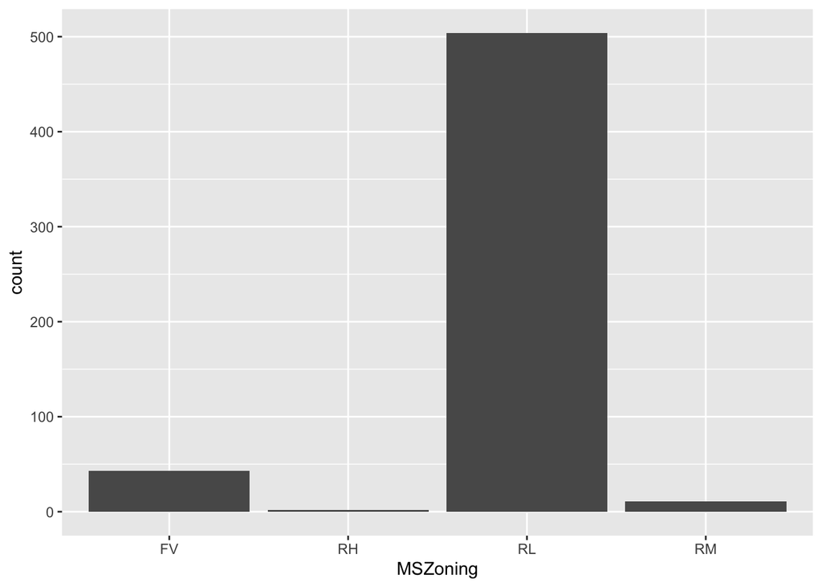

```r
price_mean_up <- mean(data$SalePrice)
houses_mean_above <- subset(data, SalePrice > price_mean_up)
ggplot(data = houses_mean_above, aes(x = MSZoning)) +geom_bar()
```

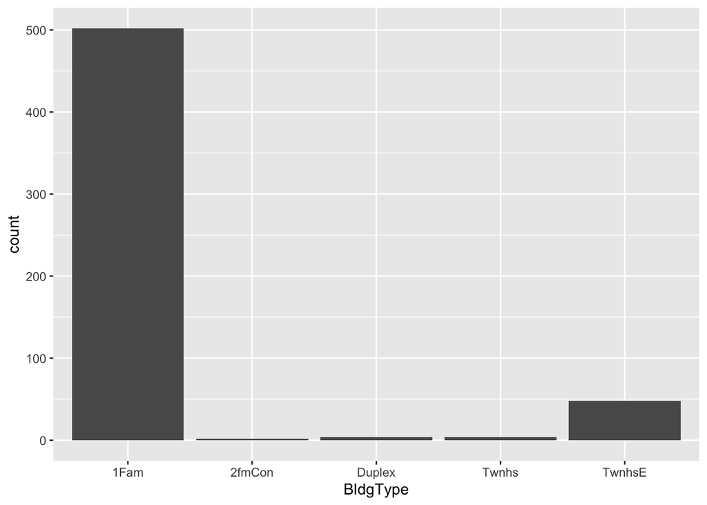

```r
ggplot(data = houses_mean_above, aes(x = BldgType)) +geom_bar()
```

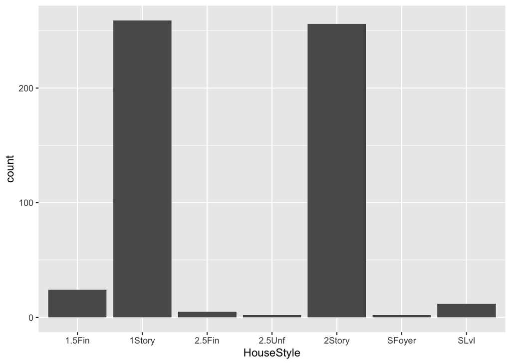

```r
ggplot(data = houses_mean_above, aes(x = HouseStyle)) +geom_bar()
```

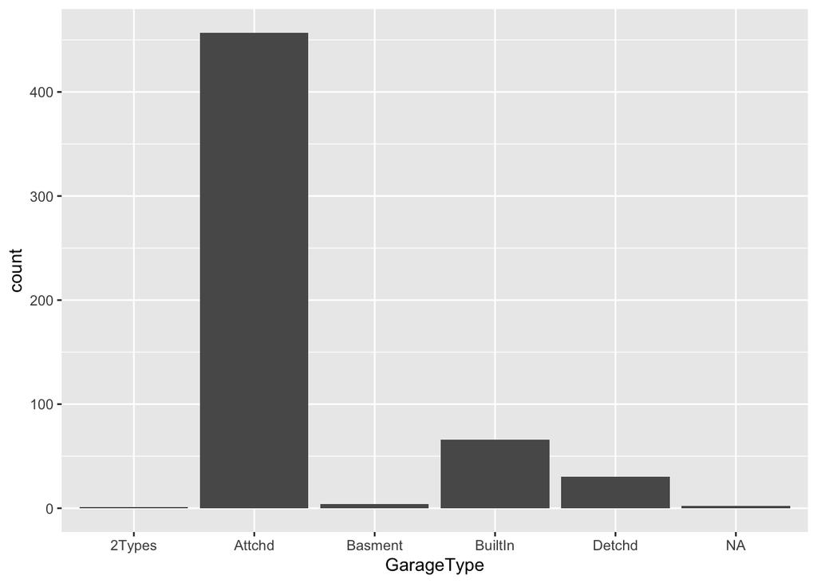

```r
ggplot(data = houses_mean_above, aes(x = GarageType)) +geom_bar()
```

Las características más comunes son las siguientes: 1) Zona donda se ubica las casas: RL (Casa residencial de baja densidad) 2) Tipo de vivienda: 1Fam (Unifamiliar) 3) Estilo de la casa: 1Story (Un nivel) 4) Tipo de Garaje: Attchd (Adjuntada a la casa)

### ¿Cuántas casas tienen piscina o garaje? ¿Como se relacionan estas características con el precio de venta?

```r
print("Counting Pools And Garages")
```

```
## [1] "Counting Pools And Garages"
```

```r
nrow(data) - table(data$PoolArea > 0)
```

```
##
## FALSE  TRUE
##     7  1453
```

```r
nrow(data) - nrow(data[data$GarageType=="NA",])
```

```
## [1] 1379
```

```r
print("")
```

```
## [1] ""
```

```r
print("Relation with the seal price")
```

```
## [1] "Relation with the seal price"
```

```r
tapply(data$SalePrice, data$PoolQC > 0, mean)
```

```
##     TRUE
## 288138.6
```

```r
tapply(data$SalePrice, data$GarageType=="NA", mean)
```

```
##    FALSE
## 185479.5
```

Como se puede ver si influyen la relación con el precio, las psicinas suelen elevar el precio de las casas

### ¿Cómo se distribuyen las ventas de casas a lo largo del tiempo entre los diferentes periodos?

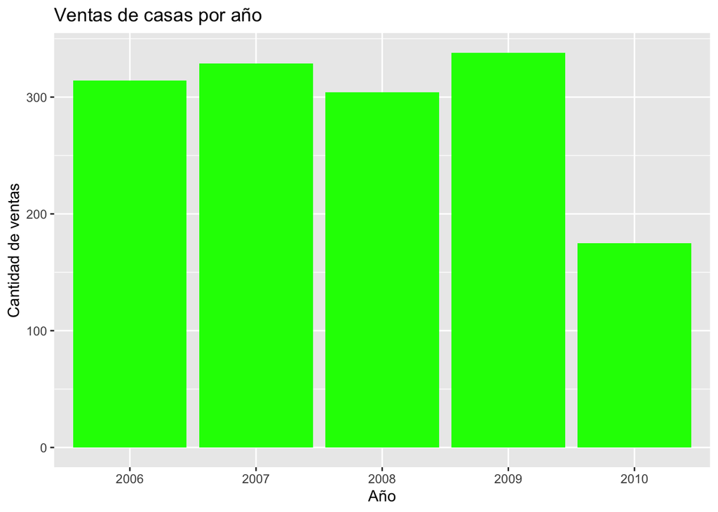

```r
ggplot(data = data, aes(x = factor(YrSold))) +
  geom_bar(fill = "green") +
  ggtitle("Ventas de casas por año") +
  xlab("Año") +
  ylab("Cantidad de ventas")
```

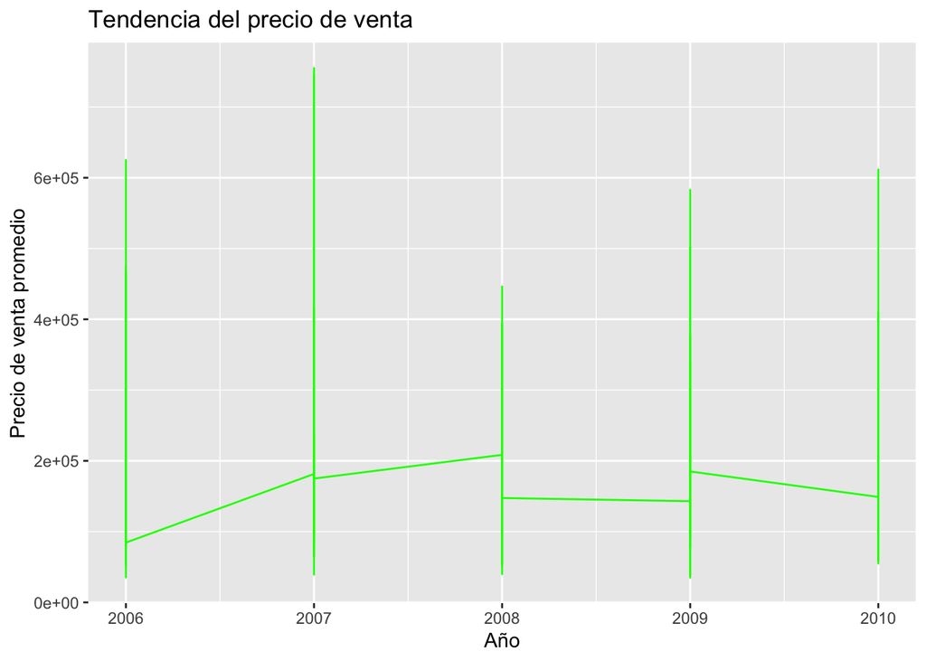

```r
ggplot(data = data, aes(x = YrSold, y = SalePrice)) +
  geom_line(color = "green") +
  ggtitle("Tendencia del precio de venta") +
  xlab("Año") +
  ylab("Precio de venta promedio")
```

Como se puede ver en las dos gráficas presentadas desde el año 2006 al 2009 existio una tendencia donde subía y bajan las ventas de las casas. Pero desde 2010 este fue en bajando.

### Preprocesamiento de datos

```r
columns_used <- c()
neighborhoodNames <- c("NoRidge", "NridgHt", "StoneBr", "Timber", "Veenker", "Somerst", "ClearCr", "Crawfor", "CollgCr", "Blmngtn", "Gilbert", "NWAmes", "SawyerW", "Mitchel", "NAmes", "NPkVill", "SWISU", "Blueste", "Sawyer", "OldTown", "Edwards", "BrkSide", "BrDale", "IDOTRR", "MeadowV")

for(n in 1:length(neighborhoodNames)) {
  # Variable minuscula para nuestro uso.
  data$neighborhood[data$Neighborhood == neighborhoodNames[n]] <- n
}
columns_used <- append(columns_used, "neighborhood")

hs <- c("1Story", "2Story", "1.5Fin",   "SLvl", "SFoyer")

for(n in 1:length(hs)) {
  # Variable minuscula para nuestro uso.
  data$houseStyle[data$HouseStyle == hs[n]] <- n
}
columns_used <- append(columns_used, "houseStyle")

 data$houseZone[data$MSZoning == "A"] <- 1
 data$houseZone[data$MSZoning == "C"] <- 2
 data$houseZone[data$MSZoning == "FV"] <- 3
 data$houseZone[data$MSZoning == "I"] <- 4
 data$houseZone[data$MSZoning == "RH"] <- 5
 data$houseZone[data$MSZoning == "RL"] <- 6
 data$houseZone[data$MSZoning == "RP"] <- 7
 data$houseZone[data$MSZoning == "RM"] <- 8
 columns_used <- append(columns_used, "houseZone")

data$houseUtilities[data$Utilities == "AllPub"] <- 1
data$houseUtilities[data$Utilities == "NoSewr"] <- 2
data$houseUtilities[data$Utilities == "NoSeWa"] <- 3
data$houseUtilities[data$Utilities == "ELO"] <- 4
columns_used <- append(columns_used, "houseUtilities")

data$roadAccess[data$Condition1 == "Artery"] <- 1
data$roadAccess[data$Condition1 == "Feedr"] <- 2
data$roadAccess[data$Condition1 == "Norm"] <- 3
data$roadAccess[data$Condition1 == "RRNn"] <- 4
data$roadAccess[data$Condition1 == "RRAn"] <- 5
data$roadAccess[data$Condition1 == "PosN"] <- 6
data$roadAccess[data$Condition1 == "PosA"] <- 7
data$roadAccess[data$Condition1 == "RRNe"] <- 8
data$roadAccess[data$Condition1 == "RRAe"] <- 9
columns_used <- append(columns_used, "roadAccess")

data$remodelated[data$YearBuilt != data$YearRemodAdd] <- 1
data$remodelated[data$YearBuilt == data$YearRemodAdd] <- 0
columns_used <- append(columns_used, "remodelated")

data$roofStyle[data$RoofStyle == "Flat"]  <- 1
data$roofStyle[data$RoofStyle == "Gable"]  <- 2
data$roofStyle[data$RoofStyle == "Gambrel"]  <- 3
data$roofStyle[data$RoofStyle == "Hip"]  <- 4
data$roofStyle[data$RoofStyle == "Mansard"]  <- 5
data$roofStyle[data$RoofStyle == "Shed"]  <- 6
columns_used <- append(columns_used, "roofStyle")

data$roofMaterial[data$RoofMatl == "ClyTile"] <- 1
data$roofMaterial[data$RoofMatl == "CompShg"] <- 2
data$roofMaterial[data$RoofMatl == "Membran"] <- 3
data$roofMaterial[data$RoofMatl == "Metal"] <- 4
data$roofMaterial[data$RoofMatl == "Roll"] <- 5
data$roofMaterial[data$RoofMatl == "Tar&Grv"] <- 6
data$roofMaterial[data$RoofMatl == "WdShake"] <- 7
data$roofMaterial[data$RoofMatl == "WdShngl"] <- 8
columns_used <- append(columns_used, "roofMaterial")

data$overallQuality <- data$OverallQual
columns_used <- append(columns_used, "overallQuality")

data$overallCondition <- data$OverallCond
columns_used <- append(columns_used, "overallCondition")


data$exteriorCondition[data$ExterCond == "Po"] <- 1
data$exteriorCondition[data$ExterCond == "Fa"] <- 2
data$exteriorCondition[data$ExterCond == "TA"] <- 3
data$exteriorCondition[data$ExterCond == "Gd"] <- 4
data$exteriorCondition[data$ExterCond == "Ex"] <- 5
columns_used <- append(columns_used, "exteriorCondition")

data$foundationMaterial[data$Foundation == "BrkTil"] <- 1
data$foundationMaterial[data$Foundation == "CBlock"] <- 2
data$foundationMaterial[data$Foundation == "PConc"] <- 3
data$foundationMaterial[data$Foundation == "Slab"] <- 4
data$foundationMaterial[data$Foundation == "Stone"] <- 5
data$foundationMaterial[data$Foundation == "Wood"] <- 6
columns_used <- append(columns_used, "foundationMaterial")

data$basement[is.na(data$BsmtQual)] <- 0
data$basement[!is.na(data$BsmtQual)] <- 1
columns_used <- append(columns_used, "basement")

data$basementCondition[data$BsmtCond == "Ex"] <- 3
data$basementCondition[data$BsmtCond == "Gd"] <- 2
data$basementCondition[data$BsmtCond != "Ex"] <- 1
data$basementCondition[data$BsmtCond != "Gd"] <- 1
data$basementCondition[is.na(data$BsmtCond)] <- 0
columns_used <- append(columns_used, "basementCondition")

data$fireplace[is.na(data$FireplaceQu)] <- 0
data$fireplace[!is.na(data$FireplaceQu)] <- 1
columns_used <- append(columns_used, "fireplace")

data$garageArea <- data$GarageArea
columns_used <- append(columns_used, "garageArea")

data$pool[is.na(data$PoolQC)] <- 0
data$pool[!is.na(data$PoolQC)] <- 1
columns_used <- append(columns_used, "pool")

data$additionalFeature[is.na(data$MiscFeature)] <- 0
data$additionalFeature[!is.na(data$MiscFeature)] <- 1
columns_used <- append(columns_used, "additionalFeature")

data$livingArea <- data$GrLivArea
columns_used <- append(columns_used, "livingArea")

data$yearBuilt <- data$YearBuilt
columns_used <- append(columns_used, "yearBuilt")


data$salePrice <- data$SalePrice
columns_used <- append(columns_used, "salePrice")

tv <- c("WD", "Oth", "New", "ConLw", "ConLI", "ConLD", "Con", "CWD", "COD")

for(n in 1:length(tv)) {
  # Variable minuscula para nuestro uso.
  data$saleType[data$SaleType == tv[n]] <- n
}
columns_used <- append(columns_used, "saleType")

msz <- c("FV", "RL", "RH", "RM" , "C (all)")

for(n in 1:length(msz)) {
  # Variable minuscula para nuestro uso.
  data$mSZoning[data$MSZoning == msz[n]] <- n
}
columns_used <- append(columns_used, "mSZoning")
```

### Borrando valores inneceesarios

```r
cleanData <- subset(data, select = columns_used)
```

### Dividiendo los datos en entrenamiento y prueba

```r
set.seed(5)
expectedResult <- cleanData$salePrice
partition <- createDataPartition(y=expectedResult,
                                 p=.75,
                                 list=F)

trainingSet <- cleanData[partition,]
testingSet <- cleanData[-partition,]
```

### Ingeniería de los Datos

Visualizamos la matriz de correlación para ver tendencias en la data.

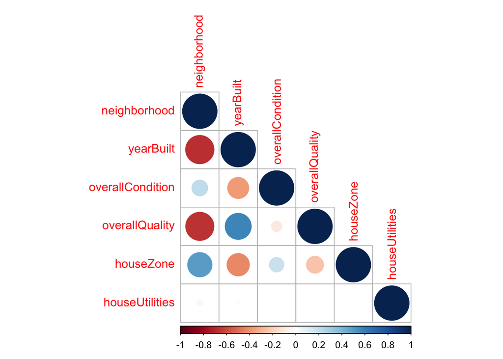

```r
correlations <- cor(cleanData[,c("neighborhood", "yearBuilt", "overallCondition", "overallQuality", "houseZone", "houseUtilities")], use="pairwise.complete.obs")
corrplot(correlations, method="circle", type="lower",  sig.level = 0.01, insig = "blank")
```

De esta figura obtenemos las siguientes conclusiones: - El año en el que se hizo la casa está correlacionado con el vecindario en el que se encuentra. - La condición de la casa tienen una correlación ligeramente negativa. Puede ser que mientras el año es menor, la condición actual reduce. - La zona donde se encuentra la casa también está ligeramente relacionada a la calidad de los materiales.

Continuamos con un segundo diagrama

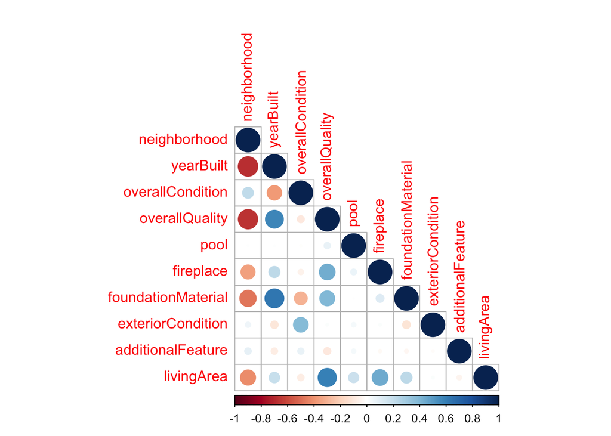

```r
correlations <- cor(cleanData[,c("neighborhood", "yearBuilt", "overallCondition", "overallQuality", "pool", "fireplace", "foundationMaterial", "exteriorCondition", "additionalFeature", "livingArea" )], use="pairwise.complete.obs")
corrplot(correlations, method="circle", type="lower",  sig.level = 0.01, insig = "blank")
```

Este diagrama nos da otra información de las variables: - Mientras mejor sea la condición del exterior, mejor es la condición en general de la casa. - la pisicna está ligeramente correlacionada con tener una fogata y con la condición del exterior de la casa. - El material usado para la base de la casa está relacionado con el año de construcción de esta. - El area de vivienda de la casa incrementa conforme la calidad de la construcción lo hace. - Una área de vivienda mayor permite tener más comodidades, como fogata o una piscina.

Si hacemos una gráfica de puntos tomando en cuenta algunas variables importantes podemos obtener más información:

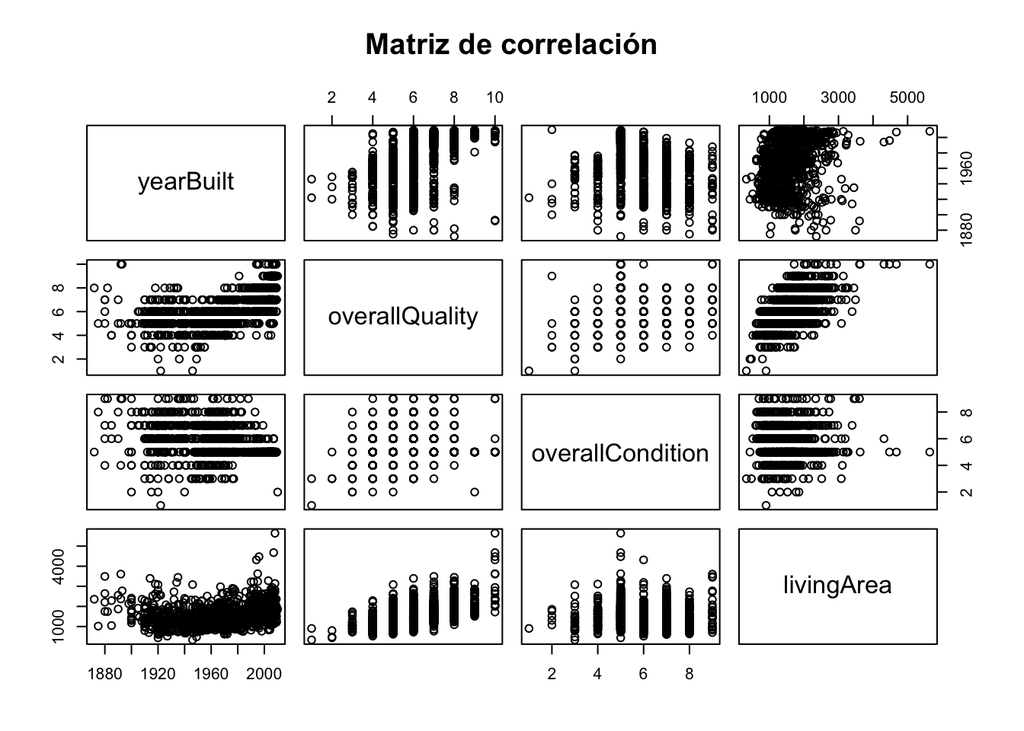

```r
pairs(~yearBuilt+overallQuality+overallCondition+livingArea,data=cleanData,
   main="Matriz de correlación")
```

- la calidad de las casas ha mejorado con el paso de los años. - El área de vivienda aumenta ligeramente con el paso del tiempo.

Tomando este análisis en cuenta, se utilizarán las siguientes variables como candidatas a mejores predicciones: - yearBuilt - el año de construcción tiene una alta influencia en la calidad de la casa, vecindario donde se encuentra, condición actual y área de vivienda. - livingArea - el area de vivienda es un factor imporante porque indica cuánto espacio puede ser aprovechado en la casa. No es la misma área que necesita una familia de 2 personas a una de 5. Además, un área mayor permite tener comodidades como piscina o fogata. - overallQuality - La calidad de la casa también es importante para el precio. Esto nos indica que el material usado es resistente. - overallCondition - La condición actual de la casa da una mejor impresión al mostrarla a posibles clientes. - pool - Una piscina aumenta el precio dado que el cliente debe tener presupuesto para mantenerla. - fireplace - en Iowa (lugar del dataset) hay inviernos con nieve, los clientes agradecerán esta comodidad

### Asegurando resultados consistentes

```r
set.seed(5)
```

### Clustering

Agrupamiento de las columnas más importantes

```r
# Definir las columnas más importantes
important_cols <- c("YrSold", "SalePrice", "YearBuilt", "YearRemodAdd", "PoolArea", "GarageArea", "OverallQual", "OverallCond", "LotFrontage", "LotArea", "GarageCars")
# Normalizar variables numericas
cols_num_norm <- data[,important_cols] <- mutate_if(data[,important_cols], is.numeric, scale)
```

Resumen de las columnas a utilizar para llevar a cabo el clustering

```r
print(summary(data[,important_cols]))
```

```
##       YrSold.V1          SalePrice.V1        YearBuilt.V1
##  Min.   :-1.3671863   Min.   :-1.838074   Min.   :-3.286697
##  1st Qu.:-0.6142282   1st Qu.:-0.641296   1st Qu.:-0.571727
##  Median : 0.1387300   Median :-0.225587   Median : 0.057352
##  Mean   : 0.0000000   Mean   : 0.000000   Mean   : 0.000000
##  3rd Qu.: 0.8916881   3rd Qu.: 0.416387   3rd Qu.: 0.951306
##  Max.   : 1.6446462   Max.   : 7.226343   Max.   : 1.282400
##
##    YearRemodAdd.V1        PoolArea.V1        GarageArea.V1
##  Min.   :-1.6887898   Min.   :-0.068668   Min.   :-2.212205
##  1st Qu.:-0.8653621   1st Qu.:-0.068668   1st Qu.:-0.647694
##  Median : 0.4424348   Median :-0.068668   Median : 0.032833
##  Mean   : 0.0000000   Mean   : 0.000000   Mean   : 0.000000
##  3rd Qu.: 0.9268040   3rd Qu.:-0.068668   3rd Qu.: 0.481841
##  Max.   : 1.2174256   Max.   :18.299910   Max.   : 4.420012
##
##    OverallQual.V1      OverallCond.V1      LotFrontage.V1       LotArea.V1
##  Min.   :-3.687150   Min.   :-4.111561   Min.   :-2.01978   Min.   :-0.923413
##  1st Qu.:-0.794879   1st Qu.:-0.517023   1st Qu.:-0.45502   1st Qu.:-0.296889
##  Median :-0.071812   Median :-0.517023   Median :-0.04324   Median :-0.104028
##  Mean   : 0.000000   Mean   : 0.000000   Mean   : 0.00000   Mean   : 0.000000
##  3rd Qu.: 0.651256   3rd Qu.: 0.381612   3rd Qu.: 0.40972   3rd Qu.: 0.108671
##  Max.   : 2.820459   Max.   : 3.077516   Max.   :10.00422   Max.   :20.511245
##                                          NA's   :259
##     GarageCars.V1
##  Min.   :-2.3646297
##  1st Qu.:-1.0265059
##  Median : 0.3116179
##  Mean   : 0.0000000
##  3rd Qu.: 0.3116179
##  Max.   : 2.9878655
##
```

Evaluación Visual de Tendencia de la data

```r
data_dist <- dist(data[,1:4])
```

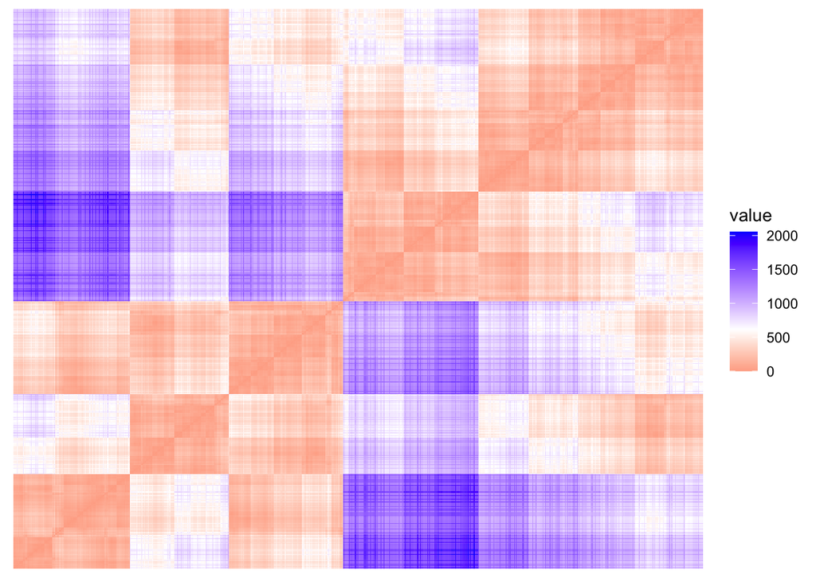

```r
fviz_dist(data_dist, show_labels=F)
```